# Regression Analysis ML

### Regression Analysis:

#### Import Required Packages:

```python
# Data visualisation and Manipulation
import numpy as np
import pandas as pd
import matplotlib.pyplot as plt
from matplotlib import style
from matplotlib.legend_handler import HandlerBase
import seaborn as sns
import scipy.stats as stats
from sklearn.preprocessing import PowerTransformer
from sklearn.decomposition import PCA

#configure
# sets matplotlib to inline and displays graphs below the corressponding cell.
%matplotlib inline
style.use('fivethirtyeight')
sns.set(style='whitegrid',color_codes=True)

#Regression
from sklearn.linear_model import LinearRegression

#model selection
from sklearn.model_selection import train_test_split,cross_validate
from sklearn.model_selection import KFold
from sklearn.model_selection import GridSearchCV
from sklearn.preprocessing import StandardScaler

#Evaluation metrics
from sklearn.metrics import mean_squared_log_error,mean_squared_error, r2_score,mean_absolute_error

# Ignore  the warnings
import warnings
warnings.filterwarnings('ignore')
```

#### Import Dataset:

This dataset was taken from data.world repository,

In this dataset contains 3047 instances and 33 features in this details about mortality rates due to cancer.

I tend to analyze the features and extract them to predict the target variable, and the target features is 'target_deathrate'.

```python
data=pd.read_csv("C:\\Users\\HP\\OneDrive\\Documents\\Cancer.csv")
data.head(5)
```

|  | avganncount | avgdeathsperyear | target_deathrate | incidencerate | medincome | popest2015 | povertypercent | studypercap | binnedinc | medianage | ... | pctprivatecoveragealone | pctempprivcoverage | pctpubliccoverage | pctpubliccoveragealone | pctwhite | pctblack | pctasian | pctotherrace | pctmarriedhouseholds | birthrate |
| --- | --- | --- | --- | --- | --- | --- | --- | --- | --- | --- | --- | --- | --- | --- | --- | --- | --- | --- | --- | --- | --- |
| 0 | 1397.0 | 469 | 164.9 | 489.8 | 61898 | 260131 | 11.2 | 499.748204 | (61494.5, 125635] | 39.3 | ... | NaN | 41.6 | 32.9 | 14.0 | 81.780529 | 2.594728 | 4.821857 | 1.843479 | 52.856076 | 6.118831 |
| 1 | 173.0 | 70 | 161.3 | 411.6 | 48127 | 43269 | 18.6 | 23.111234 | (48021.6, 51046.4] | 33.0 | ... | 53.8 | 43.6 | 31.1 | 15.3 | 89.228509 | 0.969102 | 2.246233 | 3.741352 | 45.372500 | 4.333096 |
| 2 | 102.0 | 50 | 174.7 | 349.7 | 49348 | 21026 | 14.6 | 47.560164 | (48021.6, 51046.4] | 45.0 | ... | 43.5 | 34.9 | 42.1 | 21.1 | 90.922190 | 0.739673 | 0.465898 | 2.747358 | 54.444868 | 3.729488 |
| 3 | 427.0 | 202 | 194.8 | 430.4 | 44243 | 75882 | 17.1 | 342.637253 | (42724.4, 45201] | 42.8 | ... | 40.3 | 35.0 | 45.3 | 25.0 | 91.744686 | 0.782626 | 1.161359 | 1.362643 | 51.021514 | 4.603841 |
| 4 | 57.0 | 26 | 144.4 | 350.1 | 49955 | 10321 | 12.5 | 0.000000 | (48021.6, 51046.4] | 48.3 | ... | 43.9 | 35.1 | 44.0 | 22.7 | 94.104024 | 0.270192 | 0.665830 | 0.492135 | 54.027460 | 6.796657 |

5 rows × 33 columns

### Dataset Description:

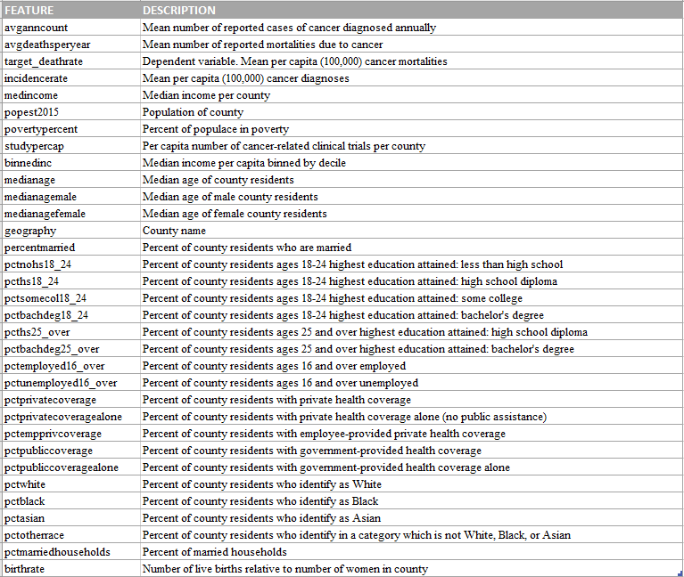

```python
data.shape
```

```
(3047, 33)
```

```python
data.info()
```

```
<class 'pandas.core.frame.DataFrame'>
RangeIndex: 3047 entries, 0 to 3046
Data columns (total 33 columns):
 #   Column                   Non-Null Count  Dtype
---  ------                   --------------  -----
 0   avganncount              3047 non-null   float64
 1   avgdeathsperyear         3047 non-null   int64
 2   target_deathrate         3047 non-null   float64
 3   incidencerate            3047 non-null   float64
 4   medincome                3047 non-null   int64
 5   popest2015               3047 non-null   int64
 6   povertypercent           3047 non-null   float64
 7   studypercap              3047 non-null   float64
 8   binnedinc                3047 non-null   object
 9   medianage                3047 non-null   float64
```

[output cut: 25 more lines]

#### List of Categorical Features :

```python
cat_df=data.select_dtypes(include='object')
cat_df.head(10)
cat_df.shape
cat_df.columns
```

```
Index(['binnedinc', 'geography'], dtype='object')
```

#### List of Numerical Features:

```python
num_df=data.select_dtypes(include='number')
num_df.shape
num_df.columns
```

```
Index(['avganncount', 'avgdeathsperyear', 'target_deathrate', 'incidencerate',
       'medincome', 'popest2015', 'povertypercent', 'studypercap', 'medianage',
       'medianagemale', 'medianagefemale', 'percentmarried', 'pctnohs18_24',
       'pcths18_24', 'pctsomecol18_24', 'pctbachdeg18_24', 'pcths25_over',
       'pctbachdeg25_over', 'pctemployed16_over', 'pctunemployed16_over',
       'pctprivatecoverage', 'pctprivatecoveragealone', 'pctempprivcoverage',
       'pctpubliccoverage', 'pctpubliccoveragealone', 'pctwhite', 'pctblack',
       'pctasian', 'pctotherrace', 'pctmarriedhouseholds', 'birthrate'],
      dtype='object')
```

#### List of Null Features:

```python
nan_df=data.loc[:, data.isna().any()]
nan_df.shape
nan_df.columns
```

```
Index(['pctsomecol18_24', 'pctemployed16_over', 'pctprivatecoveragealone'], dtype='object')
```

#### In this dataset Categorical features is 2 , Numerical features is 31 and Null value features is 3.

```python
round(data.describe().T)
```

|  | count | mean | std | min | 25% | 50% | 75% | max |
| --- | --- | --- | --- | --- | --- | --- | --- | --- |
| avganncount | 3047.0 | 606.0 | 1416.0 | 6.0 | 76.0 | 171.0 | 518.0 | 38150.0 |
| avgdeathsperyear | 3047.0 | 186.0 | 504.0 | 3.0 | 28.0 | 61.0 | 149.0 | 14010.0 |
| target_deathrate | 3047.0 | 179.0 | 28.0 | 60.0 | 161.0 | 178.0 | 195.0 | 363.0 |
| incidencerate | 3047.0 | 448.0 | 55.0 | 201.0 | 420.0 | 454.0 | 481.0 | 1207.0 |
| medincome | 3047.0 | 47063.0 | 12040.0 | 22640.0 | 38882.0 | 45207.0 | 52492.0 | 125635.0 |
| popest2015 | 3047.0 | 102637.0 | 329059.0 | 827.0 | 11684.0 | 26643.0 | 68671.0 | 10170292.0 |
| povertypercent | 3047.0 | 17.0 | 6.0 | 3.0 | 12.0 | 16.0 | 20.0 | 47.0 |
| studypercap | 3047.0 | 155.0 | 530.0 | 0.0 | 0.0 | 0.0 | 84.0 | 9762.0 |
| medianage | 3047.0 | 45.0 | 45.0 | 22.0 | 38.0 | 41.0 | 44.0 | 624.0 |
| medianagemale | 3047.0 | 40.0 | 5.0 | 22.0 | 36.0 | 40.0 | 42.0 | 65.0 |
| medianagefemale | 3047.0 | 42.0 | 5.0 | 22.0 | 39.0 | 42.0 | 45.0 | 66.0 |
| percentmarried | 3047.0 | 52.0 | 7.0 | 23.0 | 48.0 | 52.0 | 56.0 | 72.0 |
| pctnohs18_24 | 3047.0 | 18.0 | 8.0 | 0.0 | 13.0 | 17.0 | 23.0 | 64.0 |
| pcths18_24 | 3047.0 | 35.0 | 9.0 | 0.0 | 29.0 | 35.0 | 41.0 | 72.0 |
| pctsomecol18_24 | 762.0 | 41.0 | 11.0 | 7.0 | 34.0 | 40.0 | 46.0 | 79.0 |
| pctbachdeg18_24 | 3047.0 | 6.0 | 5.0 | 0.0 | 3.0 | 5.0 | 8.0 | 52.0 |
| pcths25_over | 3047.0 | 35.0 | 7.0 | 8.0 | 30.0 | 35.0 | 40.0 | 55.0 |
| pctbachdeg25_over | 3047.0 | 13.0 | 5.0 | 2.0 | 9.0 | 12.0 | 16.0 | 42.0 |
| pctemployed16_over | 2895.0 | 54.0 | 8.0 | 18.0 | 49.0 | 54.0 | 60.0 | 80.0 |
| pctunemployed16_over | 3047.0 | 8.0 | 3.0 | 0.0 | 6.0 | 8.0 | 10.0 | 29.0 |
| pctprivatecoverage | 3047.0 | 64.0 | 11.0 | 22.0 | 57.0 | 65.0 | 72.0 | 92.0 |
| pctprivatecoveragealone | 2438.0 | 48.0 | 10.0 | 16.0 | 41.0 | 49.0 | 56.0 | 79.0 |
| pctempprivcoverage | 3047.0 | 41.0 | 9.0 | 14.0 | 34.0 | 41.0 | 48.0 | 71.0 |
| pctpubliccoverage | 3047.0 | 36.0 | 8.0 | 11.0 | 31.0 | 36.0 | 42.0 | 65.0 |
| pctpubliccoveragealone | 3047.0 | 19.0 | 6.0 | 3.0 | 15.0 | 19.0 | 23.0 | 47.0 |
| pctwhite | 3047.0 | 84.0 | 16.0 | 10.0 | 77.0 | 90.0 | 95.0 | 100.0 |
| pctblack | 3047.0 | 9.0 | 15.0 | 0.0 | 1.0 | 2.0 | 11.0 | 86.0 |
| pctasian | 3047.0 | 1.0 | 3.0 | 0.0 | 0.0 | 1.0 | 1.0 | 43.0 |
| pctotherrace | 3047.0 | 2.0 | 4.0 | 0.0 | 0.0 | 1.0 | 2.0 | 42.0 |
| pctmarriedhouseholds | 3047.0 | 51.0 | 7.0 | 23.0 | 48.0 | 52.0 | 55.0 | 78.0 |
| birthrate | 3047.0 | 6.0 | 2.0 | 0.0 | 5.0 | 5.0 | 6.0 | 21.0 |

Our target feature deathrate has mean of 178.6 and median of 178.1 which says it's normally distributed. 25% death rate are below 161, 75 - 100% death rate are from count more than 195

#### Check Null values & Missing value Treatment:

```python
data.isnull().sum()
```

```
avganncount                   0
avgdeathsperyear              0
target_deathrate              0
incidencerate                 0
medincome                     0
popest2015                    0
povertypercent                0
studypercap                   0
binnedinc                     0
medianage                     0
medianagemale                 0
medianagefemale               0
geography                     0
percentmarried                0
pctnohs18_24                  0
pcths18_24                    0
pctsomecol18_24            2285
pctbachdeg18_24               0
pcths25_over                  0
pctbachdeg25_over             0
pctemployed16_over          152
pctunemployed16_over          0
pctprivatecoverage            0
pctprivatecoveragealone     609
pctempprivcoverage            0
pctpubliccoverage             0
pctpubliccoveragealone        0
pctwhite                      0
pctblack                      0
pctasian                      0
pctotherrace                  0
pctmarriedhouseholds          0
birthrate                     0
dtype: int64
```

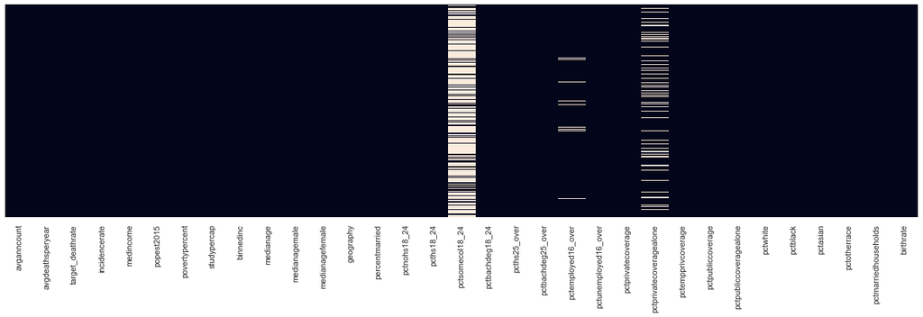

```python
plt.figure(figsize=(20, 5))
sns.heatmap(data.isnull(), yticklabels=False, cbar=False,color="purple")
```

```python
nan_all_data = (data.isnull().sum())
nan_all_data= nan_all_data.drop(nan_all_data[nan_all_data== 0].index).sort_values(ascending=False)
nan_all_data
miss_df = pd.DataFrame({'Missing Ratio' :nan_all_data})
miss_df
```

|  | Missing Ratio |
| --- | --- |
| pctsomecol18_24 | 2285 |
| pctprivatecoveragealone | 609 |
| pctemployed16_over | 152 |

### Treatment of Missing Values:

There are 2 ways to treat null values one is univariate imputation in which single columns are used another one is multivariate imputation in which more than 1 column participate in finding missing data.

Univariate imputation consitst mean,median,mode,constant,missing indicatorand and random value imputation also we can drop that row,if there is a column in which percentage of missing data is very high then we can drop that column and if missing data is below 5% then we can use central values to fill that for normally distributed data use either mean ,median or mode but for skewed data use median.

Mean and median of null valued columns are almost same. We cannot remove rows with null values, beacuse 'pctsomecol18_24' is having 2285 null values and removing the rows containing values makes 75% data loss, therefore it heavily affects model prediction.

Since pctsomecol18_24 has 2285 null values and it doesn't contribute for prediction we can drop it. We can replace null values for pctemployed16_over and pctprivatecoveragealone with their mean values.

After filling missing values we should always check for variance, variance should not change much..

we can see after filling missing values outlier get increased we can also go with random value imputation it's advantage over central value imputation is that distribution does not change much but the covariance get distorted with other variables so take care of that..

```python
data['pctemployed16_over_mean']=data['pctemployed16_over'].fillna(data['pctemployed16_over'].mean())
data['pctemployed16_over_median']=data['pctemployed16_over'].fillna(data['pctemployed16_over'].median())
data['pctemployed16_over_mode']=data['pctemployed16_over'].fillna(54)

print(data['pctemployed16_over_mode'].var())
print(data['pctemployed16_over_mean'].var())
print(data['pctemployed16_over_median'].var())
print(data['pctemployed16_over'].var())
```

```
65.69119572312188
65.69009103249324
65.69581165375632
69.14029622839475
```

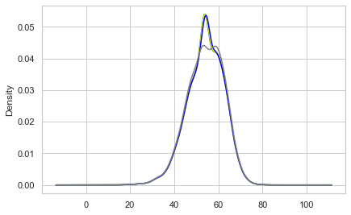

```python
fig=plt.figure()
ax=fig.add_subplot(111)
data['pctemployed16_over_mode'].plot.density(ax=ax,color='green')
data['pctemployed16_over_mean'].plot.density(ax=ax,color='yellow')
data['pctemployed16_over_median'].plot.density(ax=ax,color='blue')
data['pctemployed16_over'].plot.density(ax=ax,color='gray')
```

```python
data['pctemployed16_over_ran']=data['pctemployed16_over']
data['pctemployed16_over_ran'][data['pctemployed16_over_ran'].isnull()]=data['pctemployed16_over_ran'].dropna().sample(n=data['pctemployed16_over_ran'].isnull().sum(),random_state=1).values

print(data['pctemployed16_over'].std())
print(data['pctemployed16_over_ran'].std())
```

```
8.315064415168095
8.36444857414852
```

```python
data['pctprivatecoveragealone_mean']=data['pctprivatecoveragealone'].fillna(data['pctprivatecoveragealone'].mean())
data['pctprivatecoveragealone_median']=data['pctprivatecoveragealone'].fillna(data['pctprivatecoveragealone'].median())
data['pctprivatecoveragealone_mode']=data['pctprivatecoveragealone'].fillna(48)

print(data['pctprivatecoveragealone_mode'].var())
print(data['pctprivatecoveragealone_mean'].var())
print(data['pctprivatecoveragealone_median'].var())
print(data['pctprivatecoveragealone'].var())
```

```
81.3732292594401
81.34028899639495
81.34998779463083
101.66701694009849
```

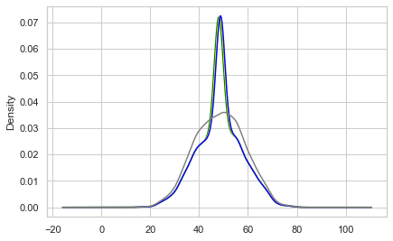

```python
fig=plt.figure()
ax=fig.add_subplot(111)
data['pctprivatecoveragealone_mode'].plot.density(ax=ax,color='green')
data['pctprivatecoveragealone_mean'].plot.density(ax=ax,color='yellow')
data['pctprivatecoveragealone_median'].plot.density(ax=ax,color='blue')
data['pctprivatecoveragealone'].plot.density(ax=ax,color='gray')
```

```python
data['pctprivatecoveragealone_ran']=data['pctprivatecoveragealone']
data['pctprivatecoveragealone_ran'][data['pctprivatecoveragealone_ran'].isnull()]=data['pctprivatecoveragealone_ran'].dropna().sample(n=data['pctprivatecoveragealone_ran'].isnull().sum(),random_state=1).values

print(data['pctprivatecoveragealone'].std())
print(data['pctprivatecoveragealone_ran'].std())
```

```
10.08300634434485
10.055861250809489
```

#### Histogram Analysis :

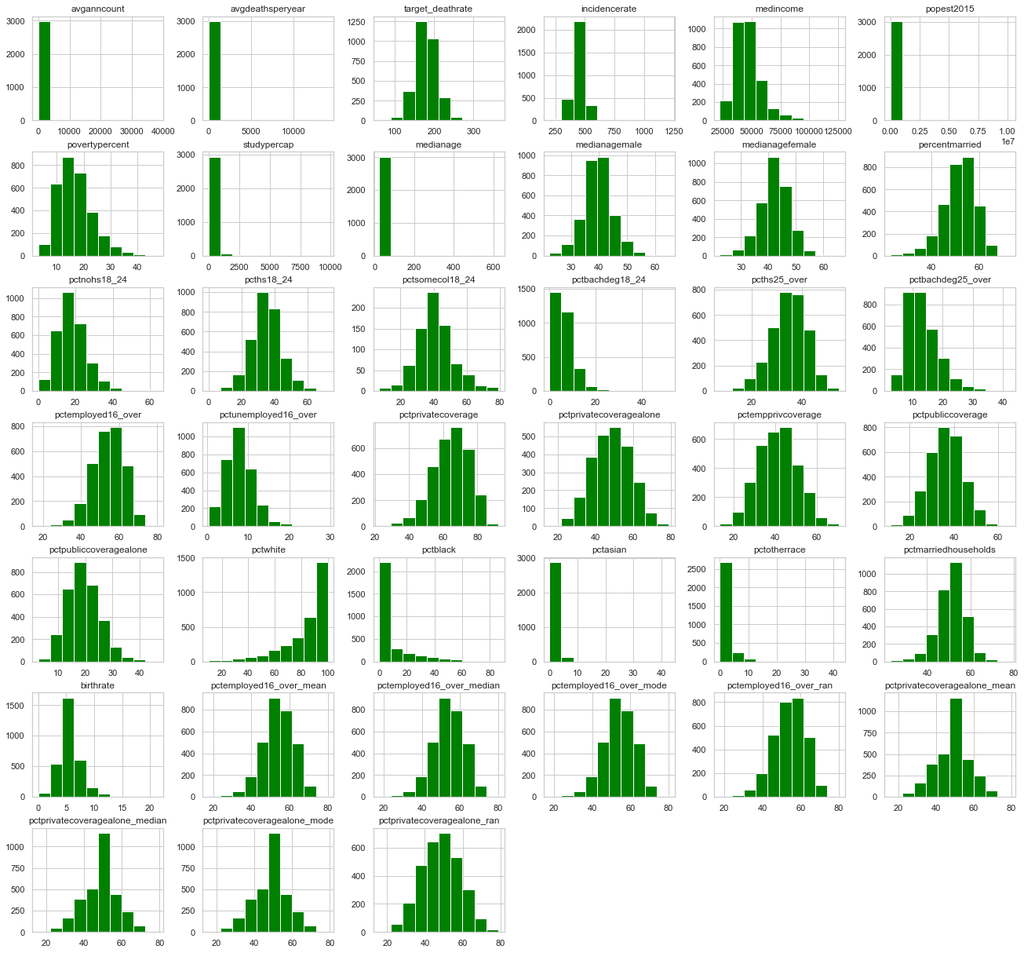

```python
data.hist(figsize=(20,20),color="green")
plt.show()
```

#### Analyzing the Target:

The target value will check before go for the model, and if it is normally distributed or not.

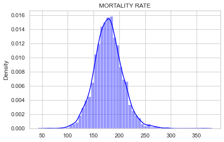

```python
sns.distplot(a=data['target_deathrate'],color='blue',axlabel=False).set_title('MORTALITY RATE')
```

#### Select All Features for Model 1:

```python
data = data[['avganncount', 'avgdeathsperyear', 'target_deathrate', 'incidencerate',
       'medincome', 'popest2015', 'povertypercent', 'studypercap',
       'medianage', 'medianagemale', 'medianagefemale',
       'percentmarried', 'pctnohs18_24', 'pcths18_24', 'pctbachdeg18_24',
       'pcths25_over', 'pctbachdeg25_over',
       'pctunemployed16_over', 'pctprivatecoverage',
       'pctempprivcoverage', 'pctpubliccoverage', 'pctpubliccoveragealone',
       'pctwhite', 'pctblack', 'pctasian', 'pctotherrace',
       'pctmarriedhouseholds', 'birthrate',
       'pctemployed16_over_ran',
       'pctprivatecoveragealone_ran']]
```

```python
x=data.drop("target_deathrate",axis=1)
y=data["target_deathrate"]
```

```python
from sklearn.model_selection import train_test_split
x_train,x_test,y_train,y_test=train_test_split(x,y,test_size=0.3,random_state=0)
print(x.shape,x_train.shape,x_test.shape)
print(y.shape, y_train.shape, y_test.shape)
```

```
(3047, 29) (2132, 29) (915, 29)
(3047,) (2132,) (915,)
```

```python
reg_lin=LinearRegression()
reg_lin.fit(x_train,y_train)
pred=reg_lin.predict(x_test)


print('Training data r-squared:', reg_lin.score(x_train, y_train))
print('Test data r-squared:', reg_lin.score(x_test, y_test))
```

```
Training data r-squared: 0.5094692996079816
Test data r-squared: 0.5434748559769025
```

```python
mse=np.sqrt(mean_squared_error(y_test,pred))
print("The Mean Square Error is ",mse)

mae=mean_absolute_error(y_test, pred)
print("The Mean absolute Error is ",mae)

r2=r2_score(y_test, pred)
print("The R square value of test accuracy",r2)
```

```
The Mean Square Error is  18.517195541618946
The Mean absolute Error is  13.949478945107984
The R square value of test accuracy 0.5434748559769025
```

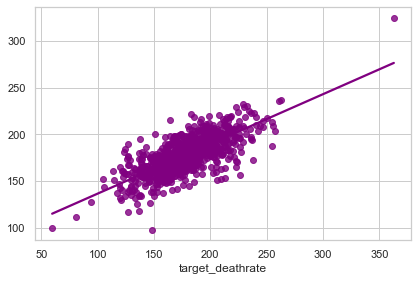

```python
#create scatterplot with regression line
sns.regplot(y_test, pred, ci=None,color="purple")
```

```python
# Evaluating the model using adjusted R2 Evaluation Metric
# Importing all necessary libraries

from sklearn.linear_model import LinearRegression
from sklearn.metrics import r2_score



# Defining the adjusted R² function
def adjusted_r2_score(actual, predictions, num_pred, num_samples):
    n = num_samples
    k = num_pred
    r2 = r2_score(actual, predictions)
    adjusted_r2 = 1 - ((1-r2) * ((n-1)/(n-k-1)))
    return adjusted_r2



# Initializing the model and fitting the model with train data
model = LinearRegression()
model.fit(x_train,y_train)



# Generating predictions over test data
predictions = model.predict(x_test)



# Evaluating the model using Adjusted R² Evaluation Metric
num_samples = x_test.shape[0]
num_predictors = x_test.shape[1]

adjusted_r2_score(y_test, predictions, num_predictors, num_samples)
```

```
0.5285152749863151
```

Without checking the correlation , the accuracy of Linear regression is 52 %

#### Selecting Features using correlation:

```python
data.corr()
```

|  | avganncount | avgdeathsperyear | target_deathrate | incidencerate | medincome | popest2015 | povertypercent | studypercap | medianage | medianagemale | ... | pctpubliccoverage | pctpubliccoveragealone | pctwhite | pctblack | pctasian | pctotherrace | pctmarriedhouseholds | birthrate | pctemployed16_over_ran | pctprivatecoveragealone_ran |
| --- | --- | --- | --- | --- | --- | --- | --- | --- | --- | --- | --- | --- | --- | --- | --- | --- | --- | --- | --- | --- | --- |
| avganncount | 1.000000 | 0.939408 | -0.143532 | 0.073553 | 0.269145 | 0.926894 | -0.135694 | 0.082071 | -0.024098 | -0.124969 | ... | -0.173548 | -0.093699 | -0.136501 | 0.031376 | 0.435071 | 0.209184 | -0.106221 | -0.034508 | 0.191831 | 0.152952 |
| avgdeathsperyear | 0.939408 | 1.000000 | -0.090715 | 0.062690 | 0.223207 | 0.977634 | -0.066918 | 0.063488 | -0.024599 | -0.148487 | ... | -0.131687 | -0.027338 | -0.187159 | 0.084607 | 0.443074 | 0.215149 | -0.160266 | -0.074420 | 0.121792 | 0.109829 |
| target_deathrate | -0.143532 | -0.090715 | 1.000000 | 0.449432 | -0.428615 | -0.120073 | 0.429389 | -0.022285 | 0.004375 | -0.021929 | ... | 0.404572 | 0.449358 | -0.177400 | 0.257024 | -0.186331 | -0.189894 | -0.293325 | -0.087407 | -0.383243 | -0.301203 |
| incidencerate | 0.073553 | 0.062690 | 0.449432 | 1.000000 | -0.001036 | 0.026912 | 0.009046 | 0.077283 | 0.018089 | -0.014733 | ... | 0.046109 | 0.040812 | -0.014510 | 0.113489 | -0.008123 | -0.208748 | -0.152176 | -0.118181 | 0.004058 | 0.077027 |
| medincome | 0.269145 | 0.223207 | -0.428615 | -0.001036 | 1.000000 | 0.235523 | -0.788965 | 0.044003 | -0.013288 | -0.091663 | ... | -0.754822 | -0.719756 | 0.167225 | -0.270232 | 0.425844 | 0.083635 | 0.446083 | -0.010195 | 0.649103 | 0.642469 |
| popest2015 | 0.926894 | 0.977634 | -0.120073 | 0.026912 | 0.235523 | 1.000000 | -0.065299 | 0.055722 | -0.025219 | -0.176608 | ... | -0.160066 | -0.041469 | -0.190095 | 0.073044 | 0.464168 | 0.241468 | -0.127979 | -0.057740 | 0.135526 | 0.115426 |
| povertypercent | -0.135694 | -0.066918 | 0.429389 | 0.009046 | -0.788965 | -0.065299 | 1.000000 | -0.055652 | -0.029280 | -0.214001 | ... | 0.651162 | 0.798642 | -0.509433 | 0.511530 | -0.157289 | 0.047096 | -0.604953 | -0.012283 | -0.691314 | -0.611885 |
| studypercap | 0.082071 | 0.063488 | -0.022285 | 0.077283 | 0.044003 | 0.055722 | -0.055652 | 1.000000 | -0.026030 | -0.036647 | ... | -0.051497 | -0.055512 | 0.023291 | -0.019761 | 0.062543 | -0.015247 | -0.051736 | 0.010676 | 0.085399 | 0.068532 |
| medianage | -0.024098 | -0.024599 | 0.004375 | 0.018089 | -0.013288 | -0.025219 | -0.029280 | -0.026030 | 1.000000 | 0.129119 | ... | 0.049060 | -0.003298 | 0.035009 | -0.017173 | -0.038424 | -0.030277 | 0.014504 | -0.008276 | -0.015020 | -0.017385 |
| medianagemale | -0.124969 | -0.148487 | -0.021929 | -0.014733 | -0.091663 | -0.176608 | -0.214001 | -0.036647 | 0.129119 | 1.000000 | ... | 0.398967 | 0.002479 | 0.398044 | -0.242748 | -0.238322 | -0.266655 | 0.222278 | -0.104105 | -0.151850 | -0.125724 |
| medianagefemale | -0.122844 | -0.144069 | 0.012048 | -0.009106 | -0.153278 | -0.177932 | -0.148164 | -0.030577 | 0.124678 | 0.933696 | ... | 0.455496 | 0.047659 | 0.339804 | -0.156728 | -0.258748 | -0.274120 | 0.161507 | -0.098813 | -0.232103 | -0.161085 |
| percentmarried | -0.106108 | -0.181029 | -0.266820 | -0.119524 | 0.355123 | -0.160463 | -0.642857 | -0.038143 | 0.046372 | 0.449986 | ... | -0.246972 | -0.459990 | 0.677420 | -0.622357 | -0.148691 | -0.104669 | 0.870261 | 0.141404 | 0.379606 | 0.271335 |
| pctnohs18_24 | -0.143327 | -0.136794 | 0.088463 | -0.170762 | -0.289383 | -0.126582 | 0.288106 | -0.090387 | 0.006178 | 0.100486 | ... | 0.318540 | 0.327270 | -0.157282 | 0.116805 | -0.217535 | 0.126256 | 0.005340 | 0.125895 | -0.319348 | -0.359929 |
| pcths18_24 | -0.182054 | -0.151418 | 0.261976 | 0.022644 | -0.190006 | -0.151821 | 0.094211 | -0.057035 | 0.050574 | 0.241310 | ... | 0.278220 | 0.234124 | 0.045306 | -0.024868 | -0.199770 | -0.060415 | 0.120040 | 0.058227 | -0.257882 | -0.233361 |
| pctbachdeg18_24 | 0.284176 | 0.259761 | -0.287817 | 0.046835 | 0.492810 | 0.248375 | -0.387122 | 0.063819 | -0.016909 | -0.034135 | ... | -0.422470 | -0.421805 | 0.069133 | -0.093614 | 0.345883 | 0.006547 | -0.000104 | -0.125073 | 0.445461 | 0.402444 |
| pcths25_over | -0.311375 | -0.295929 | 0.404589 | 0.121725 | -0.471348 | -0.311849 | 0.194361 | -0.085128 | 0.036587 | 0.318277 | ... | 0.427974 | 0.297143 | 0.188045 | -0.024445 | -0.436561 | -0.285611 | 0.062176 | 0.016600 | -0.325432 | -0.257767 |
| pctbachdeg25_over | 0.321021 | 0.293210 | -0.485477 | -0.038177 | 0.704928 | 0.297463 | -0.531600 | 0.108594 | -0.020352 | -0.131599 | ... | -0.636095 | -0.605760 | 0.048652 | -0.146409 | 0.437963 | 0.039075 | 0.098134 | -0.087940 | 0.575770 | 0.527460 |
| pctunemployed16_over | -0.009016 | 0.069701 | 0.378412 | 0.099979 | -0.453108 | 0.050768 | 0.655148 | -0.031957 | 0.018590 | -0.142737 | ... | 0.529821 | 0.655366 | -0.501755 | 0.469273 | -0.022020 | 0.028463 | -0.469609 | -0.067906 | -0.606771 | -0.466408 |
| pctprivatecoverage | 0.132244 | 0.056183 | -0.386066 | 0.105174 | 0.724175 | 0.052677 | -0.822534 | 0.092545 | 0.004665 | 0.082232 | ... | -0.720012 | -0.886234 | 0.429031 | -0.345172 | 0.189332 | -0.176300 | 0.434640 | -0.040437 | 0.655301 | 0.742742 |
| pctempprivcoverage | 0.202349 | 0.160124 | -0.267399 | 0.149825 | 0.747294 | 0.158650 | -0.683100 | 0.100063 | -0.036926 | -0.208664 | ... | -0.778315 | -0.728823 | 0.269815 | -0.237388 | 0.282484 | -0.064226 | 0.322569 | -0.093878 | 0.656852 | 0.735400 |
| pctpubliccoverage | -0.173548 | -0.131687 | 0.404572 | 0.046109 | -0.754822 | -0.160066 | 0.651162 | -0.051497 | 0.049060 | 0.398967 | ... | 1.000000 | 0.865833 | -0.133705 | 0.195597 | -0.305625 | -0.078708 | -0.362171 | -0.030531 | -0.722254 | -0.690486 |
| pctpubliccoveragealone | -0.093699 | -0.027338 | 0.449358 | 0.040812 | -0.719756 | -0.041469 | 0.798642 | -0.055512 | -0.003298 | 0.002479 | ... | 0.865833 | 1.000000 | -0.361026 | 0.330110 | -0.181380 | 0.083755 | -0.473994 | -0.004753 | -0.667245 | -0.688645 |
| pctwhite | -0.136501 | -0.187159 | -0.177400 | -0.014510 | 0.167225 | -0.190095 | -0.509433 | 0.023291 | 0.035009 | 0.398044 | ... | -0.133705 | -0.361026 | 1.000000 | -0.828459 | -0.265676 | -0.233692 | 0.596771 | -0.008958 | 0.249123 | 0.245045 |
| pctblack | 0.031376 | 0.084607 | 0.257024 | 0.113489 | -0.270232 | 0.073044 | 0.511530 | -0.019761 | -0.017173 | -0.242748 | ... | 0.195597 | 0.330110 | -0.828459 | 1.000000 | 0.016583 | -0.023001 | -0.573592 | -0.067805 | -0.314287 | -0.220563 |
| pctasian | 0.435071 | 0.443074 | -0.186331 | -0.008123 | 0.425844 | 0.464168 | -0.157289 | 0.062543 | -0.038424 | -0.238322 | ... | -0.305625 | -0.181380 | -0.265676 | 0.016583 | 1.000000 | 0.200781 | -0.086602 | -0.061947 | 0.225241 | 0.230856 |
| pctotherrace | 0.209184 | 0.215149 | -0.189894 | -0.208748 | 0.083635 | 0.241468 | 0.047096 | -0.015247 | -0.030277 | -0.266655 | ... | -0.078708 | 0.083755 | -0.233692 | -0.023001 | 0.200781 | 1.000000 | -0.027352 | 0.059829 | 0.044520 | -0.074691 |
| pctmarriedhouseholds | -0.106221 | -0.160266 | -0.293325 | -0.152176 | 0.446083 | -0.127979 | -0.604953 | -0.051736 | 0.014504 | 0.222278 | ... | -0.362171 | -0.473994 | 0.596771 | -0.573592 | -0.086602 | -0.027352 | 1.000000 | 0.102263 | 0.291146 | 0.319925 |
| birthrate | -0.034508 | -0.074420 | -0.087407 | -0.118181 | -0.010195 | -0.057740 | -0.012283 | 0.010676 | -0.008276 | -0.104105 | ... | -0.030531 | -0.004753 | -0.008958 | -0.067805 | -0.061947 | 0.059829 | 0.102263 | 1.000000 | 0.075604 | -0.035279 |
| pctemployed16_over_ran | 0.191831 | 0.121792 | -0.383243 | 0.004058 | 0.649103 | 0.135526 | -0.691314 | 0.085399 | -0.015020 | -0.151850 | ... | -0.722254 | -0.667245 | 0.249123 | -0.314287 | 0.225241 | 0.044520 | 0.291146 | 0.075604 | 1.000000 | 0.579818 |
| pctprivatecoveragealone_ran | 0.152952 | 0.109829 | -0.301203 | 0.077027 | 0.642469 | 0.115426 | -0.611885 | 0.068532 | -0.017385 | -0.125724 | ... | -0.690486 | -0.688645 | 0.245045 | -0.220563 | 0.230856 | -0.074691 | 0.319925 | -0.035279 | 0.579818 | 1.000000 |

30 rows × 30 columns

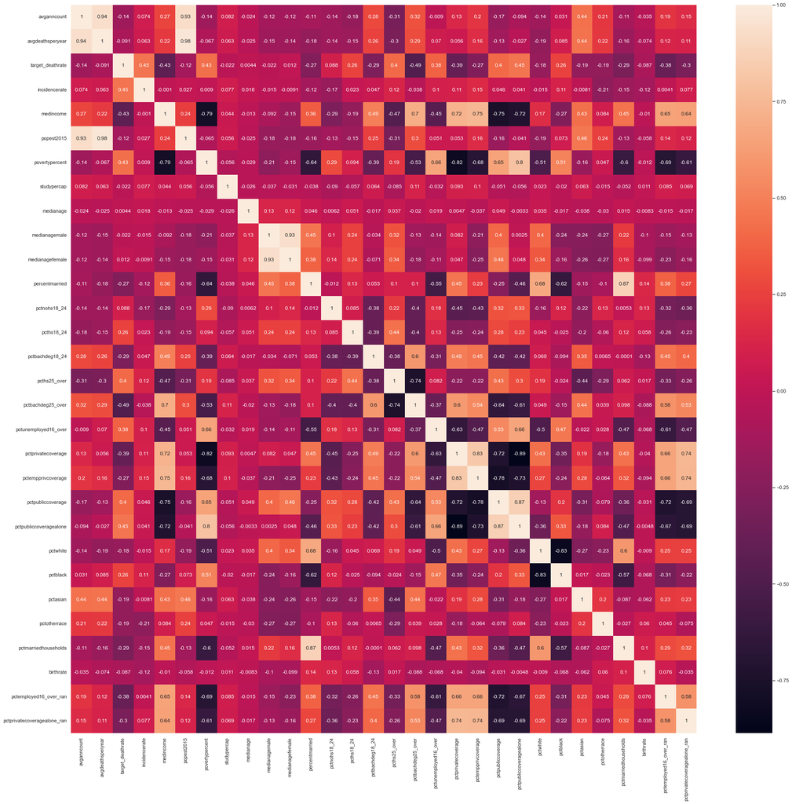

```python
mycor= data.corr()
plt.subplots(figsize=(28,28))
sns.heatmap(mycor,annot=True)
```

It is more difficult to interpret the dependable features from the above heatmap. So we define a function and set a threshold to find the most related attributes.

```python
x1=data.drop("target_deathrate",axis=1)
y1=data["target_deathrate"]
```

```python
from sklearn.model_selection import train_test_split
x1_train,x1_test,y1_train,y1_test=train_test_split(x1,y1,test_size=0.3,random_state=0)
x1_train.shape,x1_test.shape
```

```
((2132, 29), (915, 29))
```

```python
def correlation(data,threshold):
    col_corr=set() #set of all names of correlated values
    corr_matrix=data.corr()
    for i in range(len(corr_matrix.columns)):
        for j in range(i):
            if abs(corr_matrix.iloc[i,j])>threshold: #absolute coefficient value
                colname=corr_matrix.columns[i] #getting name of column
                col_corr.add(colname)
    return col_corr
```

```python
corr_features=correlation(x_train,0.7)
s=len(set(corr_features))
print(s)
corr_features
```

```
13
```

```
{'avgdeathsperyear',
 'medianagefemale',
 'pctbachdeg25_over',
 'pctblack',
 'pctemployed16_over_ran',
 'pctempprivcoverage',
 'pctmarriedhouseholds',
 'pctprivatecoverage',
 'pctprivatecoveragealone_ran',
 'pctpubliccoverage',
 'pctpubliccoveragealone',
 'popest2015',
 'povertypercent'}
```

These are the highly correlated features so we can drop it from the xtrain. We exclude them and take the remaining parameters for testing.

```python
x1_train.drop(corr_features,axis=1)
x1_test.drop(corr_features,axis=1)
```

|  | avganncount | incidencerate | medincome | studypercap | medianage | medianagemale | percentmarried | pctnohs18_24 | pcths18_24 | pctbachdeg18_24 | pcths25_over | pctunemployed16_over | pctwhite | pctasian | pctotherrace | birthrate |
| --- | --- | --- | --- | --- | --- | --- | --- | --- | --- | --- | --- | --- | --- | --- | --- | --- |
| 453 | 17.0 | 405.2 | 45710 | 0.000000 | 47.6 | 46.1 | 66.7 | 10.8 | 38.4 | 8.6 | 35.1 | 1.2 | 93.250748 | 1.238787 | 0.555318 | 4.047619 |
| 1612 | 276.0 | 476.5 | 39881 | 0.000000 | 42.6 | 41.3 | 54.7 | 21.7 | 42.2 | 4.9 | 44.9 | 8.1 | 96.816852 | 0.372147 | 0.250439 | 6.301190 |
| 2759 | 177.0 | 445.3 | 32283 | 0.000000 | 39.5 | 38.1 | 39.7 | 20.5 | 45.0 | 4.7 | 39.1 | 13.9 | 40.696988 | 0.662169 | 0.817608 | 8.279820 |
| 2870 | 612.0 | 490.4 | 56326 | 234.489849 | 37.3 | 36.1 | 46.7 | 10.7 | 32.2 | 6.9 | 34.1 | 9.8 | 80.259488 | 1.112091 | 1.447144 | 4.551301 |
| 2605 | 114.0 | 563.4 | 45269 | 0.000000 | 39.6 | 37.7 | 52.4 | 17.2 | 38.4 | 4.1 | 42.6 | 7.0 | 86.008812 | 0.192047 | 0.994126 | 5.726432 |
| ... | ... | ... | ... | ... | ... | ... | ... | ... | ... | ... | ... | ... | ... | ... | ... | ... |
| 2747 | 1373.0 | 389.4 | 44145 | 112.483409 | 51.3 | 49.9 | 53.5 | 20.9 | 29.5 | 4.6 | 25.6 | 10.0 | 91.624382 | 0.879183 | 2.712550 | 4.975285 |
| 1994 | 214.0 | 417.6 | 32662 | 0.000000 | 40.6 | 38.6 | 56.1 | 18.7 | 37.0 | 4.2 | 39.0 | 8.3 | 96.039776 | 0.612508 | 0.600109 | 7.519054 |
| 951 | 343.0 | 467.3 | 58673 | 443.595168 | 43.2 | 41.7 | 49.5 | 9.4 | 31.2 | 9.0 | 29.2 | 4.8 | 96.069810 | 0.791450 | 0.106541 | 2.874885 |
| 1238 | 33.0 | 543.8 | 27877 | 0.000000 | 38.5 | 33.7 | 32.9 | 31.2 | 30.8 | 0.0 | 30.6 | 22.1 | 27.929240 | 0.353798 | 0.166493 | 7.020548 |
| 2686 | 411.0 | 456.5 | 51175 | 0.000000 | 39.0 | 37.5 | 54.6 | 24.2 | 25.9 | 5.7 | 32.1 | 7.8 | 81.053995 | 1.245425 | 2.042678 | 5.183502 |

915 rows × 16 columns

```python
cor_matrix= data[:].corr()
cor_with_tar=cor_matrix.sort_values(['target_deathrate'],ascending=False)

print("The most relevant features (numeric) for the target are :")
cor_with_tar.target_deathrate
```

```
The most relevant features (numeric) for the target are :
```

```
target_deathrate               1.000000
incidencerate                  0.449432
pctpubliccoveragealone         0.449358
povertypercent                 0.429389
pcths25_over                   0.404589
pctpubliccoverage              0.404572
pctunemployed16_over           0.378412
pcths18_24                     0.261976
pctblack                       0.257024
pctnohs18_24                   0.088463
medianagefemale                0.012048
medianage                      0.004375
medianagemale                 -0.021929
studypercap                   -0.022285
birthrate                     -0.087407
avgdeathsperyear              -0.090715
popest2015                    -0.120073
avganncount                   -0.143532
pctwhite                      -0.177400
pctasian                      -0.186331
pctotherrace                  -0.189894
percentmarried                -0.266820
pctempprivcoverage            -0.267399
pctbachdeg18_24               -0.287817
pctmarriedhouseholds          -0.293325
pctprivatecoveragealone_ran   -0.301203
pctemployed16_over_ran        -0.383243
pctprivatecoverage            -0.386066
medincome                     -0.428615
pctbachdeg25_over             -0.485477
Name: target_deathrate, dtype: float64
```

From the comparison between the two corr matrix and corr features, it is seen that the parameters 'pctpubliccoveragealone', 'povertypercent', 'pctblack', 'medianagefemale' are to be removed. The final parameters we extract for model are: incidencerate , pcths25_over, pctpubliccoverage, pctunemployed16_over, pcths18_24 ,pctnohs18_24 ,median age.

#### Select the Features:

```python
data=data[['incidencerate','medianage','pctnohs18_24',
           'pcths18_24','pcths25_over','pctunemployed16_over',
           'pctpubliccoverage','target_deathrate']]
```

#### Univariate Analysis:

```python
def plot_num(feature):
    fig,axes=plt.subplots(1,2)
    sns.boxplot(data=data,x=feature,ax=axes[0],color='red')
    sns.distplot(a=data[feature],ax=axes[1],color="purple")
    fig.set_size_inches(15,5)
```

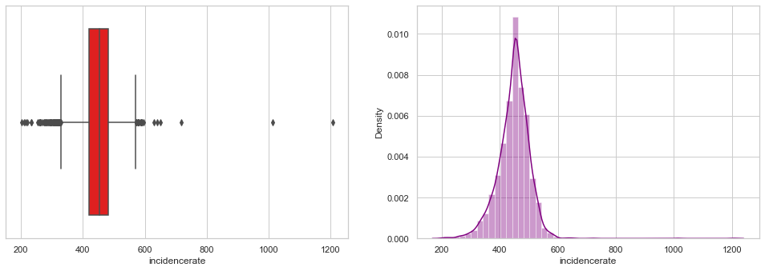

```python
plot_num('incidencerate')
```

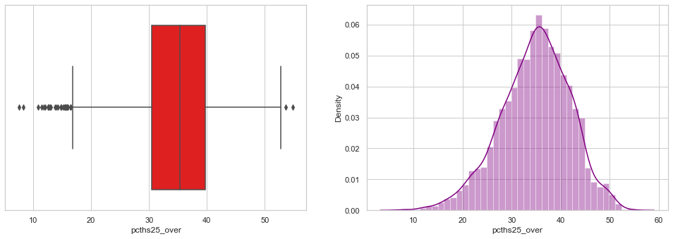

```python
plot_num('pcths25_over')
```

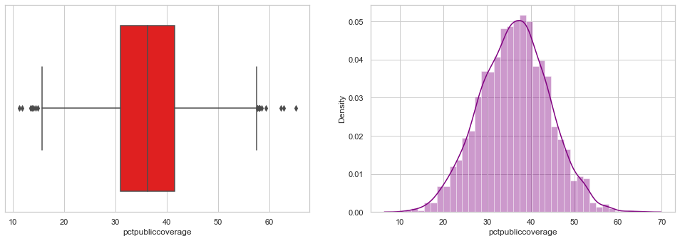

```python
plot_num('pctpubliccoverage')
```

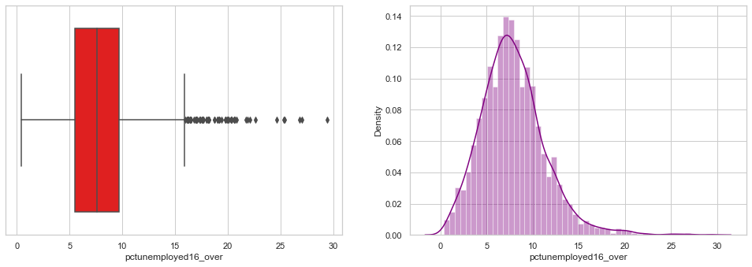

```python
plot_num('pctunemployed16_over')
```

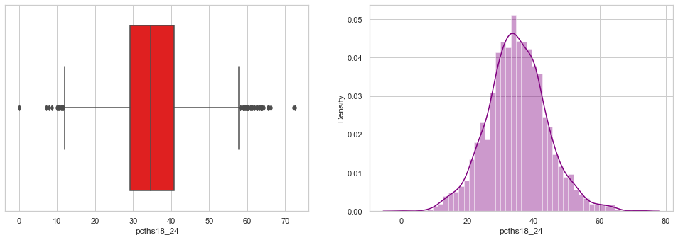

```python
plot_num('pcths18_24')
```

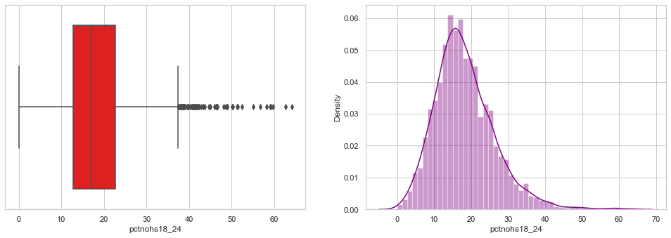

```python
plot_num('pctnohs18_24')
```

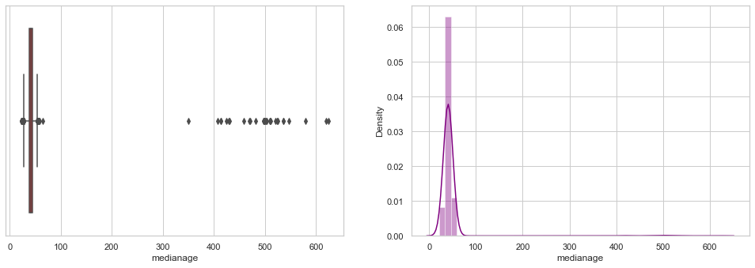

```python
plot_num('medianage')
```

There is outliers in features ,so we can use interqartile method.

```python
l=['incidencerate','medianage','pctnohs18_24',
           'pcths18_24','pcths25_over','pctunemployed16_over',
           'pctpubliccoverage','target_deathrate']

for x in l:
    q1=data[x].quantile(.25)
    q3=data[x].quantile(.75)
    iqr=q3-q1
    upper_limit=q3+1.5*iqr
    lower_limit=q1-1.5*iqr
    data[x]=np.where(data[x]>upper_limit,upper_limit,
                np.where(data[x]<lower_limit,lower_limit,data[x]))
```

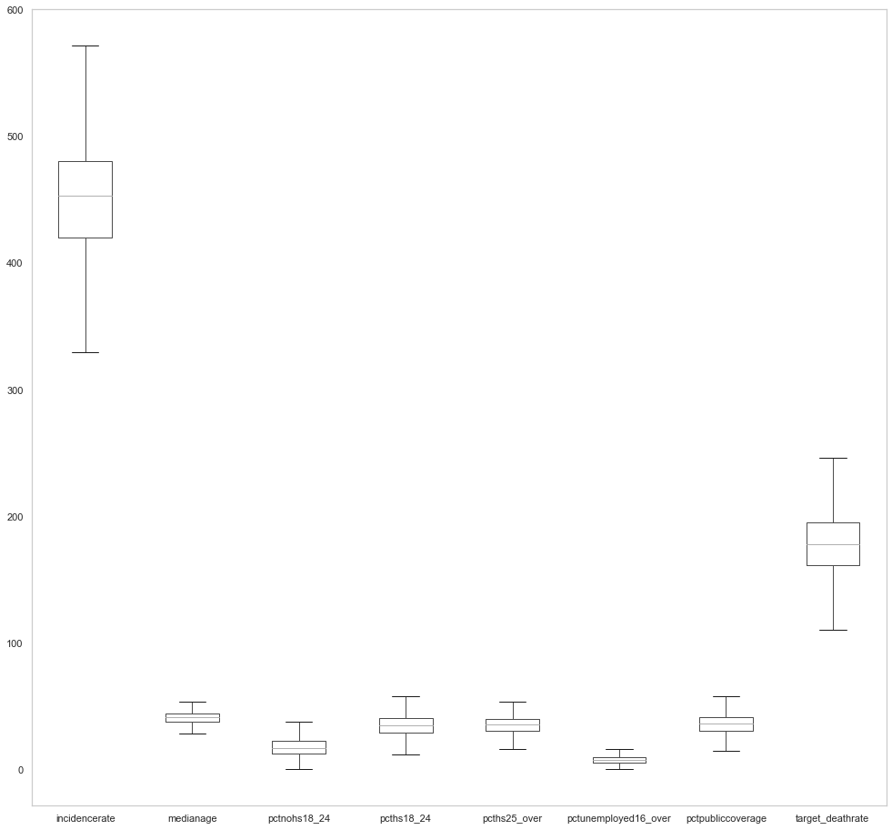

```python
fig = plt.figure(figsize =(15,15))
data.boxplot(grid = False)
```

#### Bivariate Analysis:

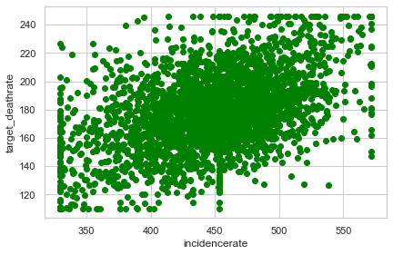

```python
fig, ax = plt.subplots()
ax.scatter(x = data['incidencerate'], y = data['target_deathrate'],color='green')
plt.ylabel('target_deathrate')
plt.xlabel('incidencerate')
plt.show()
```

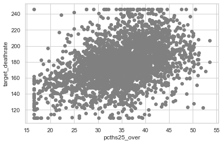

```python
fig, ax = plt.subplots()
ax.scatter(x = data['pcths25_over'], y = data['target_deathrate'],color='gray')
plt.ylabel('target_deathrate')
plt.xlabel('pcths25_over')
plt.show()
```

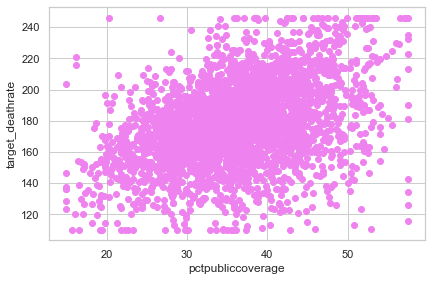

```python
fig, ax = plt.subplots()
ax.scatter(x = data['pctpubliccoverage'], y = data['target_deathrate'],color='violet')
plt.ylabel('target_deathrate')
plt.xlabel('pctpubliccoverage')
plt.show()
```

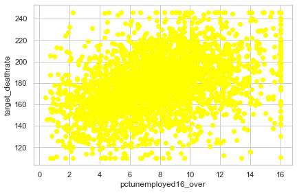

```python
fig, ax = plt.subplots()
ax.scatter(x = data['pctunemployed16_over'], y =data['target_deathrate'],color='yellow')
plt.ylabel('target_deathrate')
plt.xlabel('pctunemployed16_over')
plt.show()
```

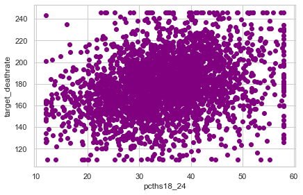

```python
fig, ax = plt.subplots()
ax.scatter(x = data['pcths18_24'], y = data['target_deathrate'],color='purple')
plt.ylabel('target_deathrate')
plt.xlabel('pcths18_24')
plt.show()
```

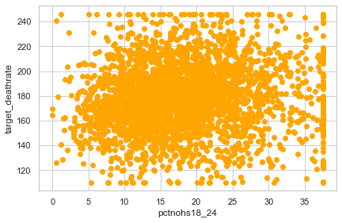

```python
fig, ax = plt.subplots()
ax.scatter(x = data['pctnohs18_24'], y = data['target_deathrate'],color='orange')
plt.ylabel('target_deathrate')
plt.xlabel('pctnohs18_24')
plt.show()
```

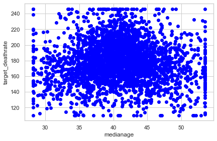

```python
fig, ax = plt.subplots()
ax.scatter(x = data['medianage'], y = data['target_deathrate'],color='blue')
plt.ylabel('target_deathrate')
plt.xlabel('medianage')
plt.show()
```

#### Model 2 - Linear Regression:

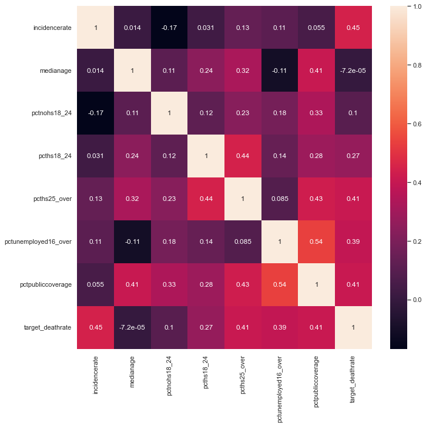

```python
mycorr1= data.corr()
plt.subplots(figsize=(10,10))
sns.heatmap(mycorr1,annot=True)
```

```python
data.corr()
```

|  | incidencerate | medianage | pctnohs18_24 | pcths18_24 | pcths25_over | pctunemployed16_over | pctpubliccoverage | target_deathrate |
| --- | --- | --- | --- | --- | --- | --- | --- | --- |
| incidencerate | 1.000000 | 0.013869 | -0.168156 | 0.031019 | 0.133152 | 0.107502 | 0.055393 | 0.446887 |
| medianage | 0.013869 | 1.000000 | 0.109689 | 0.241252 | 0.321203 | -0.105708 | 0.406646 | -0.000072 |
| pctnohs18_24 | -0.168156 | 0.109689 | 1.000000 | 0.116355 | 0.230144 | 0.181156 | 0.331474 | 0.100077 |
| pcths18_24 | 0.031019 | 0.241252 | 0.116355 | 1.000000 | 0.443484 | 0.138417 | 0.284012 | 0.267988 |
| pcths25_over | 0.133152 | 0.321203 | 0.230144 | 0.443484 | 1.000000 | 0.085004 | 0.425944 | 0.410121 |
| pctunemployed16_over | 0.107502 | -0.105708 | 0.181156 | 0.138417 | 0.085004 | 1.000000 | 0.536543 | 0.388846 |
| pctpubliccoverage | 0.055393 | 0.406646 | 0.331474 | 0.284012 | 0.425944 | 0.536543 | 1.000000 | 0.408515 |
| target_deathrate | 0.446887 | -0.000072 | 0.100077 | 0.267988 | 0.410121 | 0.388846 | 0.408515 | 1.000000 |

```python
x2 = data.drop('target_deathrate',axis=1)
y2 = data['target_deathrate']
```

```python
x2_train, x2_test, y2_train, y2_test = train_test_split(x2, y2, test_size=0.3, random_state=0)
print(x2_train.shape,x2_test.shape)
print(y2.shape, y2_train.shape, y2_test.shape)
```

```
(2132, 7) (915, 7)
(3047,) (2132,) (915,)
```

```python
reg_lin=LinearRegression()
reg_lin.fit(x2_train,y2_train)
pred=reg_lin.predict(x2_test)

print('Training data r-squared:', reg_lin.score(x2_train, y2_train))
print('Test data r-squared:', reg_lin.score(x2_test, y2_test))
```

```
Training data r-squared: 0.46466439207853494
Test data r-squared: 0.4632155298107906
```

```python
mse=np.sqrt(mean_squared_error(y2_test,pred))
print("The Mean Square Error is ",mse)

mae=mean_absolute_error(y2_test, pred)
print("The Mean absolute Error is ",mae)

r2=r2_score(y2_test, pred)
print("The R square value is",r2)
```

```
The Mean Square Error is  19.20530277169404
The Mean absolute Error is  14.637991914730396
The R square value is 0.4632155298107906
```

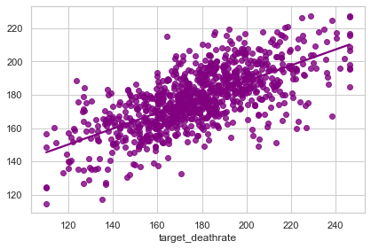

```python
#create scatterplot with regression line
sns.regplot(y2_test, pred, ci=None,color="purple")
```

```python
# Evaluating the model using adjusted R2 Evaluation Metric
# Importing all necessary libraries

from sklearn.linear_model import LinearRegression
from sklearn.metrics import r2_score



# Defining the adjusted R² function
def adjusted_r2_score(actual, predictions, num_pred, num_samples):
    n = num_samples
    k = num_pred
    r2 = r2_score(actual, predictions)
    adjusted_r2 = 1 - ((1-r2) * ((n-1)/(n-k-1)))
    return adjusted_r2



# Initializing the model and fitting the model with train data
model = LinearRegression()
model.fit(x2_train,y2_train)



# Generating predictions over test data
predictions = model.predict(x2_test)



# Evaluating the model using Adjusted R² Evaluation Metric
num_samples = x2_test.shape[0]
num_predictors = x2_test.shape[1]
adjusted_r2_score(y2_test, predictions, num_predictors, num_samples)
```

```
0.4590727610221197
```

In this linear regression model, the accuracy is ~45% only. Hence we try to tune our model better.

#### Model3- Stochastic Gradient Descent:

```python
from sklearn.linear_model import SGDRegressor
from sklearn.pipeline import make_pipeline
from sklearn.preprocessing import StandardScaler
from sklearn.pipeline import Pipeline
```

```python
re_sdg=SGDRegressor()
```

```python
re_sdg.fit(x2_train,y2_train)
```

```
SGDRegressor()
```

```python
train_mae=mean_absolute_error(y2,re_sdg.predict(x2))
print("The Mean absolute error is:",train_mae)
```

```
The Mean absolute error is: 65120949192723.66
```

```python
sgd_pl=Pipeline([("feature_scaling",StandardScaler()),("sgd",SGDRegressor())])
sgd_pl.fit(x2,y2)
train_mae=mean_absolute_error(y2,sgd_pl.predict(x2))
print("The Mean absolute is:",train_mae)
```

```
The Mean absolute is: 14.865564661401732
```

```python
score=sgd_pl.score(x2,y2)
print("R-squared",score)
```

```
R-squared 0.46430747265025907
```

The model is poor.It yields accuracy of ~46%. But the parameters were selected based on correlation features. Yet the model does not hold good. The dataset needs to be rechecked and reworked for better results.